# Simplicity and Depression - K means

# Objective:

To determine if there is a relationship between higher levels of black and white thinking and higher levels of self-reported depression in psychiatric patients hospitalized for depression.Also apply K means clustering and assign groups for model prediction

# Context:

It is common for people who tend to think of their reality as a series of black and white events to suffer from depression. Psybersquare, Inc. describes a few examples of this way of thinking by saying that those who suffer from this way of thinking think that, "If things aren't 'perfect,' then they must be "horrible." If your child isn't "brilliant" then he must be 'stupid.' If you're not 'fascinating' then you must be 'boring.'" This can be a difficult way to live since those suffering from this way of thinking may never feel that their reality is “good enough”.

# Data Sources:

Here, "Black and white thinking" is referred as "Simplicity"

```python
# Unsupervised is detecting patterns, supervised is applying the patterns to the desired output
# Supervised: we have labels => unsupervised: no target column
# Unsupervised is more about categorization and identifying trends in those categories
# Simple math behind kmeans
# Unsupervised learning has to train/test split
# Unknown outcomes at the beginning of unsupervised learning
# Uncertainty in the outcomes -> not always repeatable *
# Scaling is required *
# Features with high variability are required
# sunny - cloudy - rainy - snowy k=4
# the data available is for precipitation and type of precipitation => temperature/UV
# on the extreme case => drop the undesired attributes since they create undue variability
# EDA comes after clustering but before supervised learning

# Segmentation problems such as Amazon Customer Segmentation
# k sometimes is a business requirement,
```

```python
# To enable plotting graphs in Jupyter notebook
%matplotlib inline
```

```python
# Numerical libraries
import numpy as np

from sklearn.cluster import KMeans

# to handle data in form of rows and columns
import pandas as pd

# importing ploting libraries
import matplotlib.pyplot as plt

#importing seaborn for statistical plots
import seaborn as sns

from sklearn import metrics

import pandas as pd
```

```python
# reading the CSV file into pandas dataframe
mydata = pd.read_csv("Depression.csv")
```

```python
mydata.head()
```

|  | id | simplicity | fatalism | depression | adjsimp | adjfatal | adjdep |
| --- | --- | --- | --- | --- | --- | --- | --- |
| 0 | 1 | 0.92983 | 0.35589 | 0.59870 | 0.75934 | 0.10673 | 0.41865 |
| 1 | 2 | 0.91097 | 1.18439 | 0.72787 | 0.72717 | 0.99915 | 0.51688 |
| 2 | 3 | 0.53366 | -0.05837 | 0.53411 | 0.62176 | 0.03811 | 0.70699 |
| 3 | 4 | 0.74118 | 0.35589 | 0.56641 | 0.83522 | 0.42218 | 0.65639 |
| 4 | 5 | 0.53366 | 0.77014 | 0.50182 | 0.47697 | 0.81423 | 0.53518 |

```python
##Remove id since it is redundant
mydata.drop('id', axis=1, inplace=True)
```

```python
mydata.info()
```

```
<class 'pandas.core.frame.DataFrame'>
RangeIndex: 82 entries, 0 to 81
Data columns (total 6 columns):
 #   Column      Non-Null Count  Dtype
---  ------      --------------  -----
 0   simplicity  82 non-null     float64
 1   fatalism    82 non-null     float64
 2   depression  82 non-null     float64
 3   adjsimp     82 non-null     float64
 4   adjfatal    82 non-null     float64
 5   adjdep      82 non-null     float64
dtypes: float64(6)
memory usage: 4.0 KB
```

```python
mydata.shape
```

```
(82, 6)
```

```python
mydata.describe()
```

|  | simplicity | fatalism | depression | adjsimp | adjfatal | adjdep |
| --- | --- | --- | --- | --- | --- | --- |
| count | 82.000000 | 82.000000 | 82.000000 | 82.000000 | 82.000000 | 82.000000 |
| mean | 1.000000 | 1.000000 | 1.000001 | 1.000000 | 1.000000 | 1.000000 |
| std | 0.500000 | 0.500001 | 0.500000 | 0.499999 | 0.500000 | 0.500000 |
| min | 0.250680 | -0.058370 | 0.469530 | 0.235690 | 0.030120 | 0.234540 |
| 25% | 0.656282 | 0.563010 | 0.566410 | 0.697958 | 0.731598 | 0.596565 |
| 50% | 0.882665 | 0.977270 | 0.824750 | 0.968490 | 0.924290 | 0.967845 |
| 75% | 1.269400 | 1.391520 | 1.373730 | 1.201790 | 1.299120 | 1.261750 |
| max | 2.854080 | 2.220030 | 2.245650 | 2.949770 | 2.249310 | 2.787630 |

[figure not shown]

```python
import seaborn as sns
sns.pairplot(mydata, diag_kind='kde')
```

[figure not shown]

```python
corr = mydata.corr()
sns.heatmap(corr, annot = True)
```

```python
mydata.drop(columns = {'simplicity', 'fatalism','depression'}, inplace=True)
```

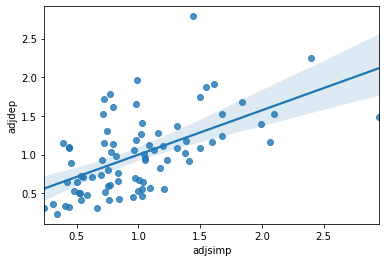

```python
sns.regplot(mydata['adjsimp'], mydata['adjdep'])
```

```python
##Scale the data
from scipy.stats import zscore

mydata_z = mydata.apply(zscore)
#sklearn standard scaler
```

```python
[i for i in range(1,10)]
```

```
[1, 2, 3, 4, 5, 6, 7, 8, 9]
```

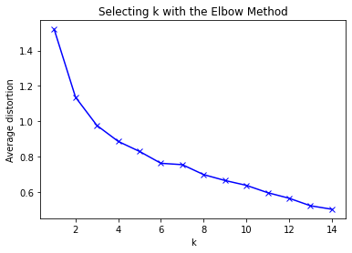

```python
#Finding optimal no. of clusters
from scipy.spatial.distance import cdist
clusters=range(1, 15)
meanDistortions=[]

for k in clusters:
    model=KMeans(n_clusters=k)
    model.fit(mydata_z)
    prediction=model.predict(mydata_z)
    meanDistortions.append(sum(np.min(cdist(mydata_z, model.cluster_centers_, 'euclidean'), axis=1))/mydata_z.shape[0])


plt.plot(clusters, meanDistortions, 'bx-')
plt.xlabel('k')
plt.ylabel('Average distortion')
plt.title('Selecting k with the Elbow Method')
```

```python
#Set the value of k=6
kmeans = KMeans(n_clusters=6, n_init = 15, random_state=2345)
```

```python
kmeans.fit(mydata_z)
```

```
KMeans(n_clusters=6, n_init=15, random_state=2345)
```

```python
centroids = kmeans.cluster_centers_
```

```python
centroids.shape
```

```
(6, 3)
```

```python
#Clculate the centroids for the columns to profile
centroid_df = pd.DataFrame(centroids, columns = list(mydata_z) )
```

```python
centroid_df
```

|  | adjsimp | adjfatal | adjdep |
| --- | --- | --- | --- |
| 0 | 0.077900 | -0.292343 | 0.564925 |
| 1 | -0.574366 | -1.351193 | -1.006300 |
| 2 | 1.835137 | 1.167825 | 1.167035 |
| 3 | 0.143136 | 0.878918 | 0.448961 |
| 4 | 0.886624 | 2.492647 | 3.597263 |
| 5 | -0.641145 | -0.085407 | -0.586397 |

```python
kmeans.labels_
```

```
array([1, 5, 1, 1, 5, 5, 1, 3, 1, 0, 1, 1, 1, 5, 5, 3, 5, 3, 5, 5, 5, 5,
       5, 5, 3, 5, 1, 1, 5, 5, 5, 5, 1, 1, 1, 5, 5, 1, 1, 1, 5, 0, 3, 5,
       0, 5, 5, 2, 0, 2, 0, 5, 2, 5, 3, 3, 5, 0, 3, 0, 0, 0, 0, 0, 2, 3,
       2, 2, 2, 0, 4, 2, 3, 3, 0, 2, 2, 3, 2, 2, 0, 3], dtype=int32)
```

```python
## creating a new dataframe only for labels and converting it into categorical variable
df_labels = pd.DataFrame(kmeans.labels_ , columns = list(['labels']))

df_labels['labels'] = df_labels['labels'].astype('category')
df_labels
```

|  | labels |
| --- | --- |
| 0 | 1 |
| 1 | 5 |
| 2 | 1 |
| 3 | 1 |
| 4 | 5 |
| ... | ... |
| 77 | 3 |
| 78 | 2 |
| 79 | 2 |
| 80 | 0 |
| 81 | 3 |

82 rows × 1 columns

```python
# Joining the label dataframe with the data frame.
df_labeled = mydata.join(df_labels)
df_labeled
```

|  | adjsimp | adjfatal | adjdep | labels |
| --- | --- | --- | --- | --- |
| 0 | 0.75934 | 0.10673 | 0.41865 | 1 |
| 1 | 0.72717 | 0.99915 | 0.51688 | 5 |
| 2 | 0.62176 | 0.03811 | 0.70699 | 1 |
| 3 | 0.83522 | 0.42218 | 0.65639 | 1 |
| 4 | 0.47697 | 0.81423 | 0.53518 | 5 |
| ... | ... | ... | ... | ... |
| 77 | 0.72117 | 1.50039 | 1.14913 | 3 |
| 78 | 1.59752 | 2.05016 | 1.16443 | 2 |
| 79 | 2.39515 | 0.88910 | 2.24452 | 2 |
| 80 | 1.31493 | 1.04058 | 1.37153 | 0 |
| 81 | 0.97903 | 1.23973 | 1.65687 | 3 |

82 rows × 4 columns

```python
df_labeled['labels'].value_counts()
```

```
5    26
1    16
0    14
3    13
2    12
4     1
Name: labels, dtype: int64
```

```python
# Let us try with K = 3 (to demonstrate the 3d plot using mplot3d)
from mpl_toolkits.mplot3d import Axes3D
```

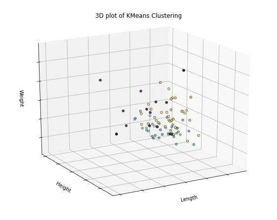

```python
## 3D plots of clusters

fig = plt.figure(figsize=(8, 6))
ax = Axes3D(fig, rect=[0, 0, .95, 1], elev=20, azim=60)
k3_model=KMeans(3)
k3_model.fit(mydata_z)
labels = k3_model.labels_
ax.scatter(mydata_z.iloc[:, 0], mydata_z.iloc[:, 1], mydata_z.iloc[:, 2],c=labels.astype(np.float), edgecolor='k')
ax.w_xaxis.set_ticklabels([])
ax.w_yaxis.set_ticklabels([])
ax.w_zaxis.set_ticklabels([])
ax.set_xlabel('Length')
ax.set_ylabel('Height')
ax.set_zlabel('Weight')
ax.set_title('3D plot of KMeans Clustering')
```

```python
# Let us try with K = 3 (to demonstrate the 3d plot)
final_model=KMeans(3, random_state=2)
final_model.fit(mydata)
prediction=final_model.predict(mydata)

#Append the prediction
mydata["GROUP"] = prediction
print("Groups Assigned : \n")
mydata[["adjdep", "GROUP"]]
```

```
Groups Assigned :
```

|  | adjdep | GROUP |
| --- | --- | --- |
| 0 | 0.41865 | 2 |
| 1 | 0.51688 | 1 |
| 2 | 0.70699 | 2 |
| 3 | 0.65639 | 2 |
| 4 | 0.53518 | 1 |
| ... | ... | ... |
| 77 | 1.14913 | 0 |
| 78 | 1.16443 | 0 |
| 79 | 2.24452 | 1 |
| 80 | 1.37153 | 0 |
| 81 | 1.65687 | 0 |

82 rows × 2 columns

```python
mydata['GROUP'].value_counts()
```

```
0    42
1    26
2    14
Name: GROUP, dtype: int64
```

# EDA

```
array([[<matplotlib.axes._subplots.AxesSubplot object at 0x7fe5f3dd5f70>,
      dtype=object)
```

[figure not shown]

```python
mydata.boxplot(by = 'GROUP',  layout=(2,4), figsize=(20, 15))
```